# Can you guess how many stars a reviewer will give based on the words they use?

A Szwec  
21/11/2015

### Introduction

**Description of question:**  
Can a model be built to relate the keywords in reviews to the number of stars given by the users? If so, does the presence of keywords relating to dietary requirements affect the likelihood of a five star rating?

**Rationale for studying it:**

- To study if there are benefits and advantages for Cafes/Restaurants that cater for dietary requirements?
- This would be valuable to Cafes/Restaurants to see if they could capture additional clientele / better serve their current clientele by catering for dietary requirements. This would allow them to expand into other markets and increase revenue.

### Methods and data

- There are ~900k reviews for cafes or restaurants representing 59.4% of reviews
- The reviews were extracted and processed to create basic features such as number of words, special characters and capital letters
- Additional processing washed out common words (stopwords), punctutation, and stemmed words then created a document term matrix (dtm) which includes the frequency of each word in each review
- The top 20 words amongst the reviews were used as features in the final model. These words were selected by reducing the sparsity of the dtm
- This feature matrix was split into a training and test set and used to produce the model
- The model chosen was a random forest due to its ability to learn non-linear relationships and combine many weak learners to create a good model. The target variable was Stars.
- Additionaly hierachal and kmeans clustering were used to look at the relationship between the words

### Results

See report for full result set.

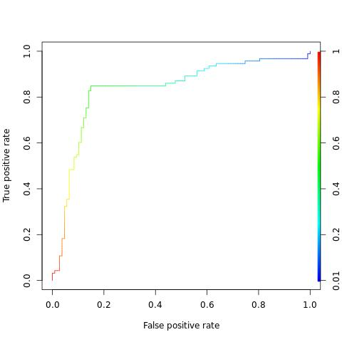

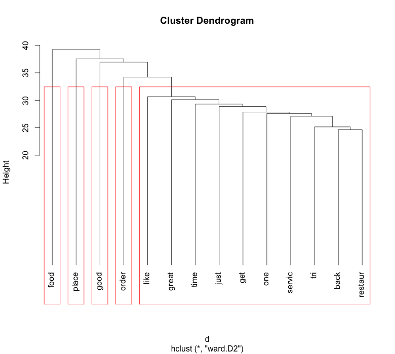

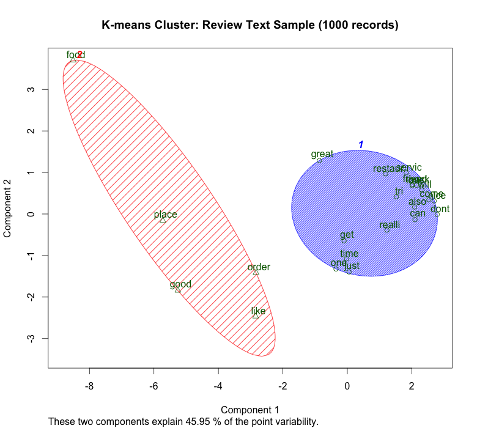

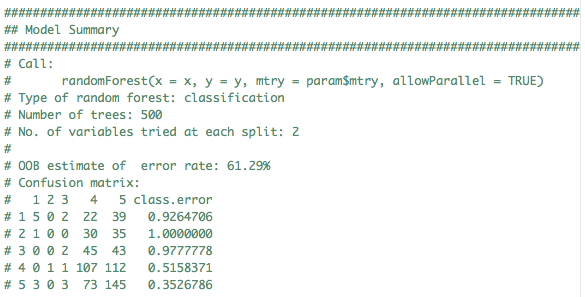

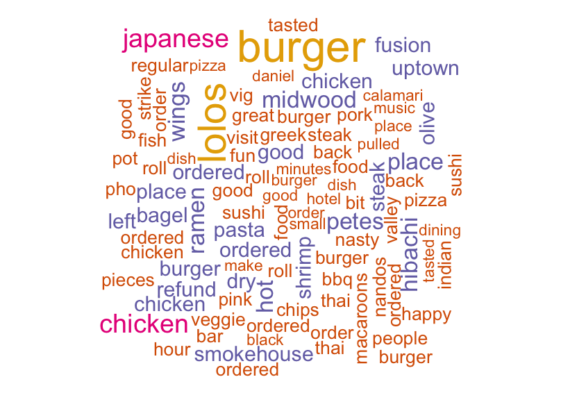

[figure not shown]

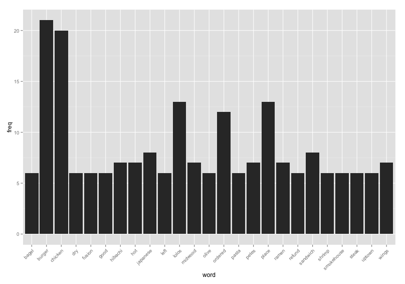

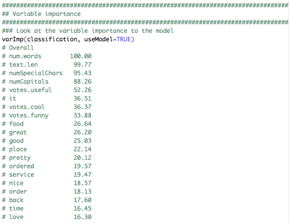

### Discussion

**Test set performance**  
The model was not very good at predicting the number of stars on the test set. Test set accuracy : 0.3521

**Conclusion**  
Yes, a model can be built to relate the keywords in reviews to the number of stars given by users. However, more work needs to be done to improve model performance Suggestions to improve performance include: use a larger training/test set, try a different model type, use kfolds cross-validation No, keywords relating to dietary requirements do not have a significant impact on predicting the number of stars. The flag indicating the review contains a dietary requirement was not used in the model according to varImp()